# Practical M/C Learning

Anirudh Jain

### Executive Summary

Using devices such as Jawbone Up, Nike FuelBand, and Fitbit it is now possible to collect a large amount of data about personal activity relatively inexpensively. These type of devices are part of the quantified self movement – a group of enthusiasts who take measurements about themselves regularly to improve their health, to find patterns in their behavior, or because they are tech geeks. One thing that people regularly do is quantify how much of a particular activity they do, but they rarely quantify how well they do it.

In this project, our goal will be to use data from accelerometers on the belt, forearm, arm, and dumbell of 6 participants and build a model to predict classe.

### Libraries Included

```r
library(tidyselect)
library(factoextra)
library(FactoMineR)
library(rlang)
library(graphics)
library(ggplot2)
library(caret)
library(rattle)
library(parallel)
library(doParallel)
```

### Data Preparation

```r
train <- read.csv("train")
test <- read.csv("test")

## dividing train into training & validate
set.seed(7)
intrain <- createDataPartition(train$classe,p=0.7,list = FALSE)
training <- train[intrain,]
validate <- train[-intrain,]

## removing near zero variate variables from training,validate & test
nzv <- nearZeroVar(training)
training_nzv <- training[,-nzv]
validate_nzv <- validate[,-nzv]
test_nzv <- test[,-nzv]
##since classe varible is last, nzv indices will correctly fit the test data

## removing columns with NA values constituting more than 90% of responses.
inNA <- which(colSums(is.na((training_nzv)))>=.9*nrow(training_nzv))
training_tidy <- training_nzv[,-inNA]
validate_tidy <- validate_nzv[,-inNA]
test_tidy <- test_nzv[,-inNA]

## Removing first 6 columns not required for prediction.
training_tidy <- training_tidy[,-(1:6)]
validate_tidy <- validate_tidy[,-(1:6)]
test_tidy <- test_tidy[,-(1:6)]
```

### Data Exploration & Pre-processing

Preprocessing is done to standardize the data and cross validation training control is set.

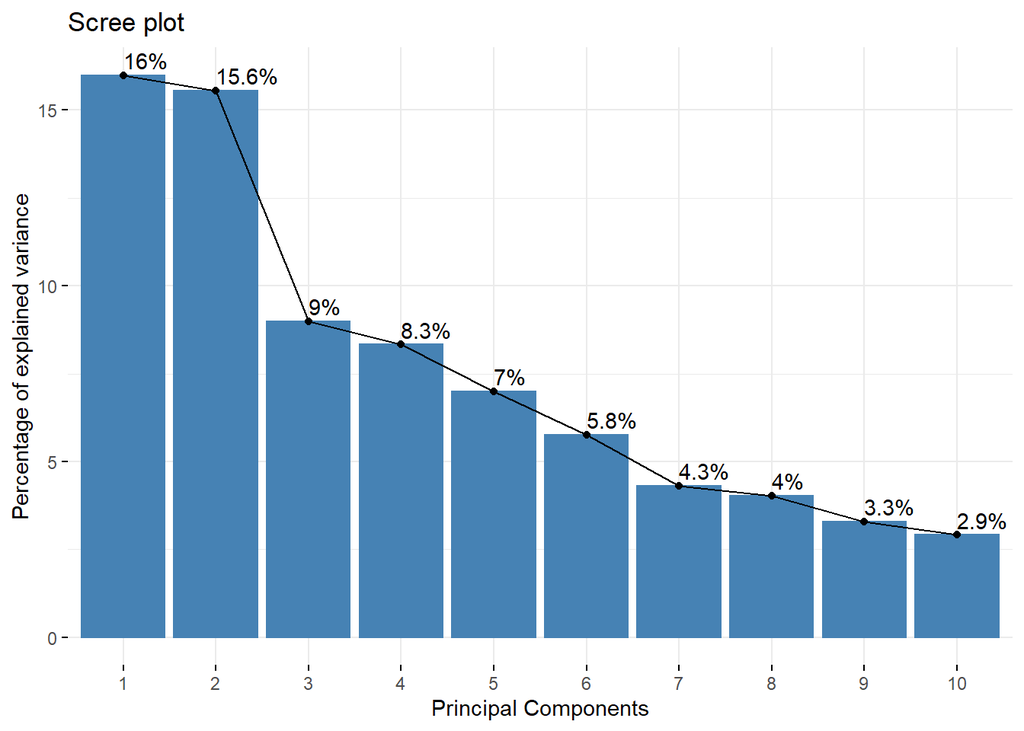

```r
## Principal Component analysis
kaka <- PCA(training_tidy[,-53],graph = F)
fviz_eig(kaka, xlab = "Principal Components", ylab ="Percentage of explained variance", addlabels = T )
```

```r
preObj <- preProcess(training_tidy[,-53],method = c("center","scale"))
training_final <- predict(preObj,training_tidy[,-53])
training_final <-data.frame(training_final,classe=training_tidy$classe)
validate_final <- predict(preObj,validate_tidy[,-53])
test_final <- predict(preObj,test_tidy)
trControl <- trainControl(method="cv", number=5,allowParallel = TRUE)
```

### Modelling

Three models are used - rpart, rf & gbm. Parrallel computing is used to speed up the computations.

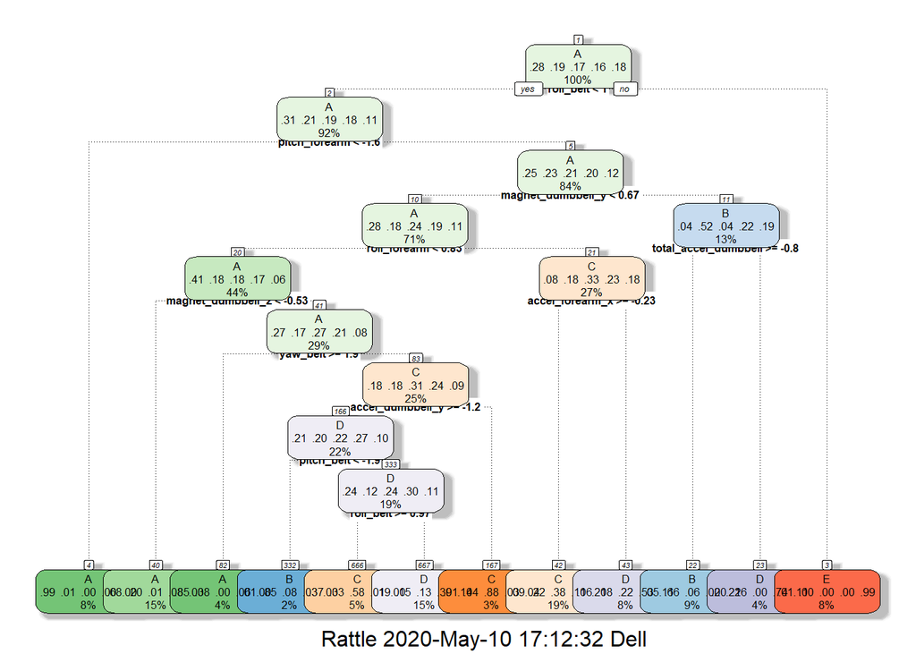

```r
##1 RPART
model_rpart <- train(classe~., data=training_final, method="rpart", trControl=trControl,tuneLength = 6)
fancyRpartPlot(model_rpart$finalModel,cex=.5)
```

```r
pred_rpart <- predict(model_rpart,validate_final)
confusionMatrix(pred_rpart,validate_tidy$classe)[2:3]
```

```
## $table
##           Reference
## Prediction    A    B    C    D    E
##          A 1246  226   14   86   24
##          B   16  440   40   15  134
##          C  197  253  736  119  268
##          D  209  220  236  744  177
##          E    6    0    0    0  479
##
## $overall
##       Accuracy          Kappa  AccuracyLower  AccuracyUpper   AccuracyNull
##   6.193713e-01   5.216713e-01   6.068245e-01   6.317996e-01   2.844520e-01
## AccuracyPValue  McnemarPValue
##   0.000000e+00  7.415035e-285
```

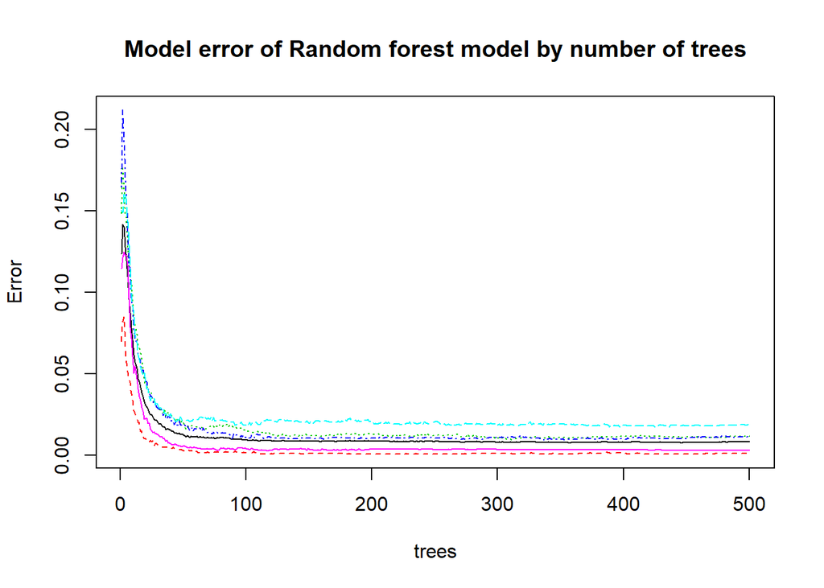

```r
##2 RF
## Parallel Processing to reduce time
cluster <- makeCluster(detectCores() - 1)
registerDoParallel(cluster)
model_rf <- train(classe~., data=training_final, method="rf",verbose = FALSE,trControl = trControl)
plot(model_rf$finalModel,main = "Model error of Random forest model by number of trees")
```

```r
pred_rf <- predict(model_rf,validate_final)
confusionMatrix(pred_rf,validate_tidy$classe)[2:3]
```

```
## $table
##           Reference
## Prediction    A    B    C    D    E
##          A 1672    8    0    0    0
##          B    2 1127    6    0    0
##          C    0    4 1018   18    0
##          D    0    0    2  945    1
##          E    0    0    0    1 1081
##
## $overall
##       Accuracy          Kappa  AccuracyLower  AccuracyUpper   AccuracyNull
##      0.9928632      0.9909715      0.9903653      0.9948517      0.2844520
## AccuracyPValue  McnemarPValue
##      0.0000000            NaN
```

```r
varImp(model_rf)
```

```
## rf variable importance
##
##   only 20 most important variables shown (out of 52)
##
##                   Overall
## roll_belt          100.00
## yaw_belt            74.00
## magnet_dumbbell_z   66.93
## pitch_forearm       59.14
## magnet_dumbbell_y   58.61
## pitch_belt          57.24
## magnet_dumbbell_x   49.56
## roll_forearm        45.34
## magnet_belt_z       43.65
## accel_dumbbell_y    43.20
## accel_belt_z        40.12
## roll_dumbbell       37.72
## magnet_belt_y       37.35
## accel_dumbbell_z    35.73
## roll_arm            32.67
## accel_forearm_x     32.03
## yaw_dumbbell        29.47
## gyros_belt_z        28.87
## accel_dumbbell_x    28.44
## gyros_dumbbell_y    26.90
```

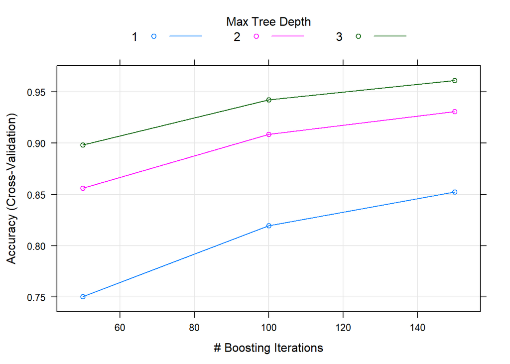

```r
##3 GBM model
model_gbm <- train(classe~., data=training_final, method="gbm", trControl=trControl, verbose=FALSE)
plot(model_gbm)
```

```r
pred_gbm <- predict(model_gbm,validate_final)
confusionMatrix(pred_gbm,validate_tidy$classe)[2:3]
```

```
## $table
##           Reference
## Prediction    A    B    C    D    E
##          A 1639   38    0    1    5
##          B   25 1071   33    4   18
##          C    9   28  979   35   11
##          D    1    2   12  916   10
##          E    0    0    2    8 1038
##
## $overall
##       Accuracy          Kappa  AccuracyLower  AccuracyUpper   AccuracyNull
##   9.588785e-01   9.479740e-01   9.534877e-01   9.638081e-01   2.844520e-01
## AccuracyPValue  McnemarPValue
##   0.000000e+00   6.096396e-08
```

### Prediction using the best model i.e. random forest model

All 20 cases are predicted using the random forest model

```r
pred_test <- predict(model_rf,test_final)
pred_test
```

```
##  [1] B A B A A E D B A A B C B A E E A B B B
## Levels: A B C D E
```